# Practical Machine Learning Final Project

Stacy Hoehn

3/12/2020

## Introduction

In the study described at http://groupware.les.inf.puc-rio.br/har, six young participants were asked to perform one set of 10 repetitions of the Unilateral Dumbbell Biceps Curl in five different fashions: exactly according to the specification (Class A), throwing the elbows to the front (Class B), lifting the dumbbell only halfway (Class C), lowering the dumbbell only halfway (Class D) and throwing the hips to the front (Class E). In this project, our goal is to use data from accelerometers on the belt, forearm, arm, and dumbell of these participants to predict if the task was performed correctly (Class A) or what type of mistake (Class B-E) was made.

## Importing the Data

The training data for this project are available at https://d396qusza40orc.cloudfront.net/predmachlearn/pml-training.csv, while the test data are available at https://d396qusza40orc.cloudfront.net/predmachlearn/pml-testing.csv. We begin by importing these data sets and loading all necessary packages.

```r
library(caret)
library(rattle)
library(randomForest)
library(gbm)

trainingData <- read.csv("https://d396qusza40orc.cloudfront.net/predmachlearn/pml-training.csv",header=T,na.strings=c("", "NA"))

testData <- read.csv("https://d396qusza40orc.cloudfront.net/predmachlearn/pml-testing.csv",header=T,na.strings=c("", "NA"))
```

## Cross-Validation

We split the training data imported above into two sets to use for cross-validation.

```r
set.seed(314)
inTrain  <- createDataPartition(trainingData$classe, p=0.7, list=FALSE)
trainingSet <- trainingData[inTrain, ]
validationSet  <- trainingData[-inTrain, ]
```

## Preparing the Data

When we view the training set, many of the columns appear to be filled mostly with NAs. We explore this further below.

```r
naPerColumn <- colSums(is.na(trainingSet))
table(naPerColumn)
```

```
## naPerColumn
##     0 13457
##    60   100
```

Of the 160 columns in the dataset, 60 of them do not contain any NAs, while the remaining columns contain mostly NAs. We remove those 100 columns from the training and validation sets.

```r
completeColumns <- colnames(trainingSet[,naPerColumn == 0])

trainingSet <- trainingSet[,completeColumns]
validationSet <- validationSet[,completeColumns]
```

Next, we check to see if any of the columns have near-zero variance . It turns out that only the “new_window” column has near-zero variance; we remove that column from the training and validation data.

```r
NZV <- nearZeroVar(trainingSet)
colnames(trainingSet[NZV])
```

```
## [1] "new_window"
```

```r
trainingSet <- trainingSet[, -NZV]
validationSet <- validationSet[,-NZV]
```

We next inspect the remaining columns to see if we are done preparing our data.

```r
#preview the first few entries in the dataset
head(trainingSet,n=4)
```

```
##   X user_name raw_timestamp_part_1 raw_timestamp_part_2   cvtd_timestamp
## 1 1  carlitos           1323084231               788290 05/12/2011 11:23
## 3 3  carlitos           1323084231               820366 05/12/2011 11:23
## 4 4  carlitos           1323084232               120339 05/12/2011 11:23
## 6 6  carlitos           1323084232               304277 05/12/2011 11:23
##   num_window roll_belt pitch_belt yaw_belt total_accel_belt gyros_belt_x
## 1         11      1.41       8.07    -94.4                3         0.00
## 3         11      1.42       8.07    -94.4                3         0.00
## 4         12      1.48       8.05    -94.4                3         0.02
## 6         12      1.45       8.06    -94.4                3         0.02
##   gyros_belt_y gyros_belt_z accel_belt_x accel_belt_y accel_belt_z
## 1            0        -0.02          -21            4           22
## 3            0        -0.02          -20            5           23
## 4            0        -0.03          -22            3           21
## 6            0        -0.02          -21            4           21
```

[output cut: 45 more lines]

The first six columns contain primarily identifier-type information that is not likely to be helpful for our models. As such, we remove those columns from our training and validation sets.

```r
trainingSet <- trainingSet[,-(1:6)]
validationSet <- validationSet[,-(1:6)]
```

## Building the Models

Now that we have prepared our data, we are ready to begin building models. We will use decision trees, random forests, and boosting with trees.

### Decision Tree

We begin with a decision tree model.

```r
TreeFit <- train(classe~.,method="rpart",data=trainingSet)
print(TreeFit$finalModel)
```

```
## n= 13737
##
## node), split, n, loss, yval, (yprob)
##       * denotes terminal node
##
##  1) root 13737 9831 A (0.28 0.19 0.17 0.16 0.18)
##    2) roll_belt< 130.5 12595 8695 A (0.31 0.21 0.19 0.18 0.11)
##      4) pitch_forearm< -33.95 1124    6 A (0.99 0.0053 0 0 0) *
##      5) pitch_forearm>=-33.95 11471 8689 A (0.24 0.23 0.21 0.2 0.12)
##       10) magnet_dumbbell_y< 438.5 9653 6928 A (0.28 0.18 0.24 0.19 0.11)
##         20) roll_forearm< 123.5 6003 3561 A (0.41 0.18 0.18 0.17 0.062) *
##         21) roll_forearm>=123.5 3650 2446 C (0.078 0.18 0.33 0.23 0.18) *
##       11) magnet_dumbbell_y>=438.5 1818  880 B (0.031 0.52 0.045 0.22 0.19) *
##    3) roll_belt>=130.5 1142    6 E (0.0053 0 0 0 0.99) *
```

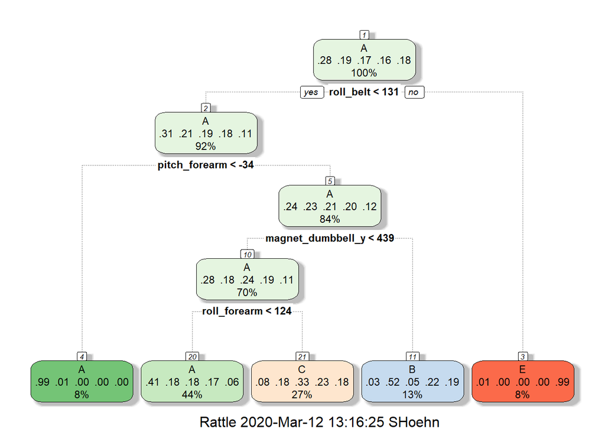

```r
fancyRpartPlot(TreeFit$finalModel)
```

We can see from the information given above that our decision tree makes use of four variables: roll_belt, pitch_forearm, magnet_dumbbell_y, and roll_forearm.

We now apply this model to our validation set to determine the out of sample error.

```r
predictionsTree <- predict(TreeFit, validationSet,method="class")
confusionMatrix(predictionsTree,validationSet$classe)
```

```
## Confusion Matrix and Statistics
##
##           Reference
## Prediction    A    B    C    D    E
##          A 1516  502  476  435  151
##          B   30  355   27  175  146
##          C  120  282  523  354  290
##          D    0    0    0    0    0
##          E    8    0    0    0  495
##
## Overall Statistics
##
##                Accuracy : 0.4909
##                  95% CI : (0.4781, 0.5038)
##     No Information Rate : 0.2845
##     P-Value [Acc > NIR] : < 2.2e-16
##
##                   Kappa : 0.3344
##
##  Mcnemar's Test P-Value : NA
##
## Statistics by Class:
##
##                      Class: A Class: B Class: C Class: D Class: E
## Sensitivity            0.9056  0.31168  0.50975   0.0000  0.45749
## Specificity            0.6286  0.92035  0.78473   1.0000  0.99833
## Pos Pred Value         0.4922  0.48431  0.33333      NaN  0.98410
## Neg Pred Value         0.9437  0.84783  0.88346   0.8362  0.89093
## Prevalence             0.2845  0.19354  0.17434   0.1638  0.18386
## Detection Rate         0.2576  0.06032  0.08887   0.0000  0.08411
## Detection Prevalence   0.5234  0.12455  0.26661   0.0000  0.08547
## Balanced Accuracy      0.7671  0.61602  0.64724   0.5000  0.72791
```

While this is a fairly simple model to understand and use, the drawback is that the model only has an accuracy of 0.4909, giving an out of sample error rate of 0.5091. It does especially bad at detecting class D, which corresponds to lowering the dumbbell only halfway.

### Random Forest

The next model we fit to the data is a random forest.

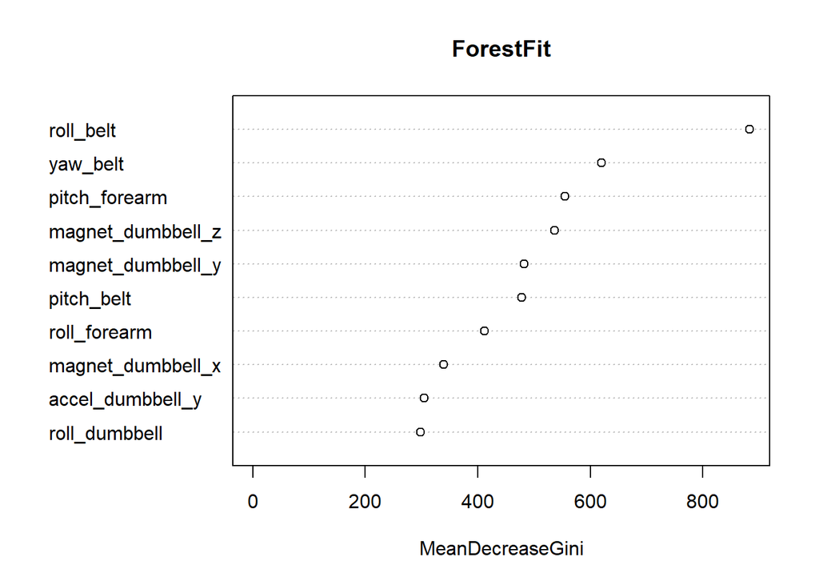

```r
ForestFit <- randomForest(classe~.,data=trainingSet)
varImpPlot(ForestFit,n.var=10)
```

We can see from the plot above that the most important variables in the random forest model are roll_belt, yaw_belt, pitch_forearm, magnet_dumbbell_z, magnet_dumbbell_y, and pitch_belt.

We now apply this model to our validation set to determine the out of sample error.

```r
predictionsForest <- predict(ForestFit, validationSet,method="class")
confusionMatrix(predictionsForest,validationSet$classe)
```

```
## Confusion Matrix and Statistics
##
##           Reference
## Prediction    A    B    C    D    E
##          A 1672    4    0    0    0
##          B    2 1129    5    0    0
##          C    0    6 1020   10    2
##          D    0    0    1  953    0
##          E    0    0    0    1 1080
##
## Overall Statistics
##
##                Accuracy : 0.9947
##                  95% CI : (0.9925, 0.9964)
##     No Information Rate : 0.2845
##     P-Value [Acc > NIR] : < 2.2e-16
##
##                   Kappa : 0.9933
##
##  Mcnemar's Test P-Value : NA
##
## Statistics by Class:
##
##                      Class: A Class: B Class: C Class: D Class: E
## Sensitivity            0.9988   0.9912   0.9942   0.9886   0.9982
## Specificity            0.9991   0.9985   0.9963   0.9998   0.9998
## Pos Pred Value         0.9976   0.9938   0.9827   0.9990   0.9991
## Neg Pred Value         0.9995   0.9979   0.9988   0.9978   0.9996
## Prevalence             0.2845   0.1935   0.1743   0.1638   0.1839
## Detection Rate         0.2841   0.1918   0.1733   0.1619   0.1835
## Detection Prevalence   0.2848   0.1930   0.1764   0.1621   0.1837
## Balanced Accuracy      0.9989   0.9949   0.9952   0.9942   0.9990
```

This model performs much better, with an accuracy rate of 0.9947 (and thus an out of sample error rate of 0.0053). The model performs well across all classes in the validation set.

### Boosting with Trees

Finally, we create a model that uses boosting with trees.

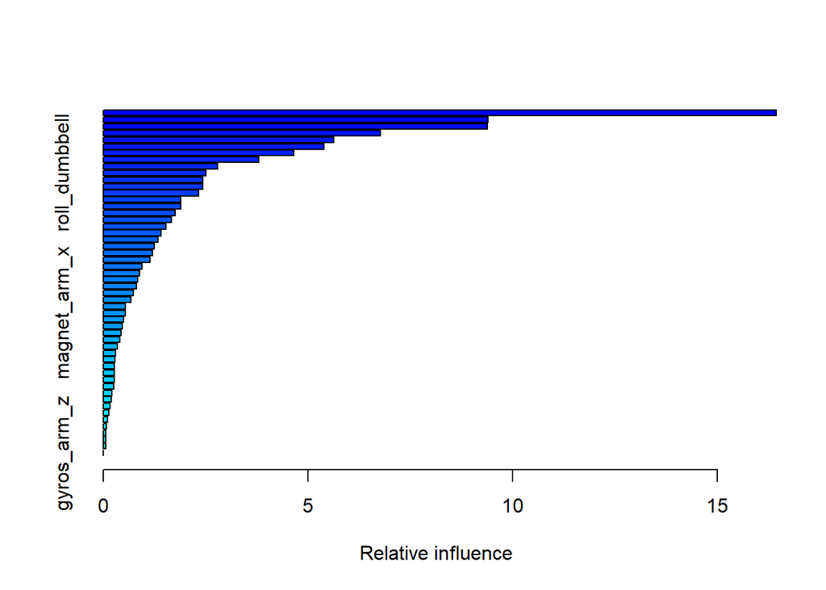

```
##                                       var      rel.inf
## roll_belt                       roll_belt 16.446466702
## pitch_forearm               pitch_forearm  9.410637290
## yaw_belt                         yaw_belt  9.385129741
## magnet_dumbbell_z       magnet_dumbbell_z  6.778832122
## magnet_dumbbell_y       magnet_dumbbell_y  5.636992422
## roll_forearm                 roll_forearm  5.400128112
## pitch_belt                     pitch_belt  4.659298677
## magnet_belt_z               magnet_belt_z  3.797101049
## gyros_belt_z                 gyros_belt_z  2.802013630
## roll_dumbbell               roll_dumbbell  2.510620221
## accel_dumbbell_y         accel_dumbbell_y  2.441940114
## magnet_forearm_z         magnet_forearm_z  2.428588996
## accel_forearm_x           accel_forearm_x  2.322920232
## accel_forearm_z           accel_forearm_z  1.901412539
## yaw_arm                           yaw_arm  1.895881857
## accel_dumbbell_z         accel_dumbbell_z  1.759097216
## gyros_dumbbell_y         gyros_dumbbell_y  1.671788664
## accel_dumbbell_x         accel_dumbbell_x  1.535307504
## magnet_belt_x               magnet_belt_x  1.406453237
## magnet_dumbbell_x       magnet_dumbbell_x  1.335254820
## magnet_arm_z                 magnet_arm_z  1.243467077
## magnet_belt_y               magnet_belt_y  1.204306875
## magnet_forearm_x         magnet_forearm_x  1.139534082
## accel_belt_z                 accel_belt_z  0.946823280
## magnet_arm_y                 magnet_arm_y  0.894606014
## gyros_arm_y                   gyros_arm_y  0.847100096
## roll_arm                         roll_arm  0.810283778
## gyros_belt_y                 gyros_belt_y  0.741887828
## accel_arm_x                   accel_arm_x  0.672931721
## gyros_dumbbell_x         gyros_dumbbell_x  0.539240968
## magnet_arm_x                 magnet_arm_x  0.537047330
## magnet_forearm_y         magnet_forearm_y  0.489835740
## accel_forearm_y           accel_forearm_y  0.468081951
## total_accel_forearm   total_accel_forearm  0.433285719
## total_accel_dumbbell total_accel_dumbbell  0.411522940
## pitch_dumbbell             pitch_dumbbell  0.342420108
## gyros_arm_x                   gyros_arm_x  0.300396171
## gyros_dumbbell_z         gyros_dumbbell_z  0.289161951
## pitch_arm                       pitch_arm  0.275318138
## yaw_dumbbell                 yaw_dumbbell  0.270416589
## accel_arm_y                   accel_arm_y  0.265475329
## gyros_forearm_y           gyros_forearm_y  0.249848714
## gyros_forearm_z           gyros_forearm_z  0.213596905
## accel_arm_z                   accel_arm_z  0.203113193
## total_accel_belt         total_accel_belt  0.163566692
## gyros_belt_x                 gyros_belt_x  0.141088624
## total_accel_arm           total_accel_arm  0.109598735
## yaw_forearm                   yaw_forearm  0.069714611
## accel_belt_x                 accel_belt_x  0.066434255
## gyros_forearm_x           gyros_forearm_x  0.065094148
## accel_belt_y                 accel_belt_y  0.063818977
## gyros_arm_z                   gyros_arm_z  0.005116316
```

```r
fitControl <- trainControl(method = "repeatedcv",
                           number = 5,
                           repeats = 1)
BoostingFit <- train(classe~.,method="gbm",data=trainingSet,trControl = fitControl,verbose=FALSE)
summary(BoostingFit)
```

We can see from the above output that the roll_belt, pitch_forearm, yaw_belt, magnet_dumbbell_z, magnet_dumbbell_y, and roll_forearm variables have the most influence on this model.

We now apply this model to our validation set to determine the out of sample error.

```r
predictionsBoost <- predict(BoostingFit,validationSet,method="class")
confusionMatrix(predictionsBoost,validationSet$classe)
```

```
## Confusion Matrix and Statistics
##
##           Reference
## Prediction    A    B    C    D    E
##          A 1649   47    1    2    1
##          B   16 1056   19    4   11
##          C    4   33  991   32    7
##          D    4    0   14  919   13
##          E    1    3    1    7 1050
##
## Overall Statistics
##
##                Accuracy : 0.9626
##                  95% CI : (0.9575, 0.9673)
##     No Information Rate : 0.2845
##     P-Value [Acc > NIR] : < 2.2e-16
##
##                   Kappa : 0.9527
##
##  Mcnemar's Test P-Value : 4.209e-06
##
## Statistics by Class:
##
##                      Class: A Class: B Class: C Class: D Class: E
## Sensitivity            0.9851   0.9271   0.9659   0.9533   0.9704
## Specificity            0.9879   0.9895   0.9844   0.9937   0.9975
## Pos Pred Value         0.9700   0.9548   0.9288   0.9674   0.9887
## Neg Pred Value         0.9940   0.9826   0.9927   0.9909   0.9934
## Prevalence             0.2845   0.1935   0.1743   0.1638   0.1839
## Detection Rate         0.2802   0.1794   0.1684   0.1562   0.1784
## Detection Prevalence   0.2889   0.1879   0.1813   0.1614   0.1805
## Balanced Accuracy      0.9865   0.9583   0.9751   0.9735   0.9840
```

This model has an accuracy rate of 0.9626, giving an out of sample error rate of 0.0374. Thus, it performs pretty well, but not quite as well as the random forest model.

## Making Predictions

Since the random forest model performed the best, we use that model to make predictions for the test data set.

```r
testData <- testData[,completeColumns[1:59]]
testData <- testData[,-(1:7)]
```

Now that the data has been prepared, we make predictions for the test data using our random forest model. These values will be entered into the course project prediction quiz.

```r
testPredictionsRF <- predict(ForestFit,testData,method="class")
testPredictionsRF
```

```
##  1  2  3  4  5  6  7  8  9 10 11 12 13 14 15 16 17 18 19 20
##  B  A  B  A  A  E  D  B  A  A  B  C  B  A  E  E  A  B  B  B
## Levels: A B C D E
```